# 9/12 lecture

For the exam you will be asked to calculate probabilities. If using R, we have to say which commands are used. Calculators and laptops are allowed.

Back to the titanic data set.

```r
titanic <- read.csv("../projects/titanic/titanic.csv")
ls.str(titanic)
```

```
## age :  num [1:1309] 29 0.917 2 30 25 ...
## pclass :  int [1:1309] 1 1 1 1 1 1 1 1 1 1 ...
## sex :  chr [1:1309] "female" "male" "female" "male" "female" "male" "female" ...
## survived :  int [1:1309] 1 1 0 0 0 1 1 0 1 0 ...
```

We want to isolate specific columns, which we do with the `$` notation.

```r
alive <- titanic$survived
count.alive <- sum(alive)
count.alive
```

```
## [1] 500
```

Say we want to figure out the precentage of survivors, then we could run

```r
prop.alive = count.alive / length(titanic$survived)
prop.alive
```

```
## [1] 0.381971
```

If we want to get the vector of all ages, then we would run

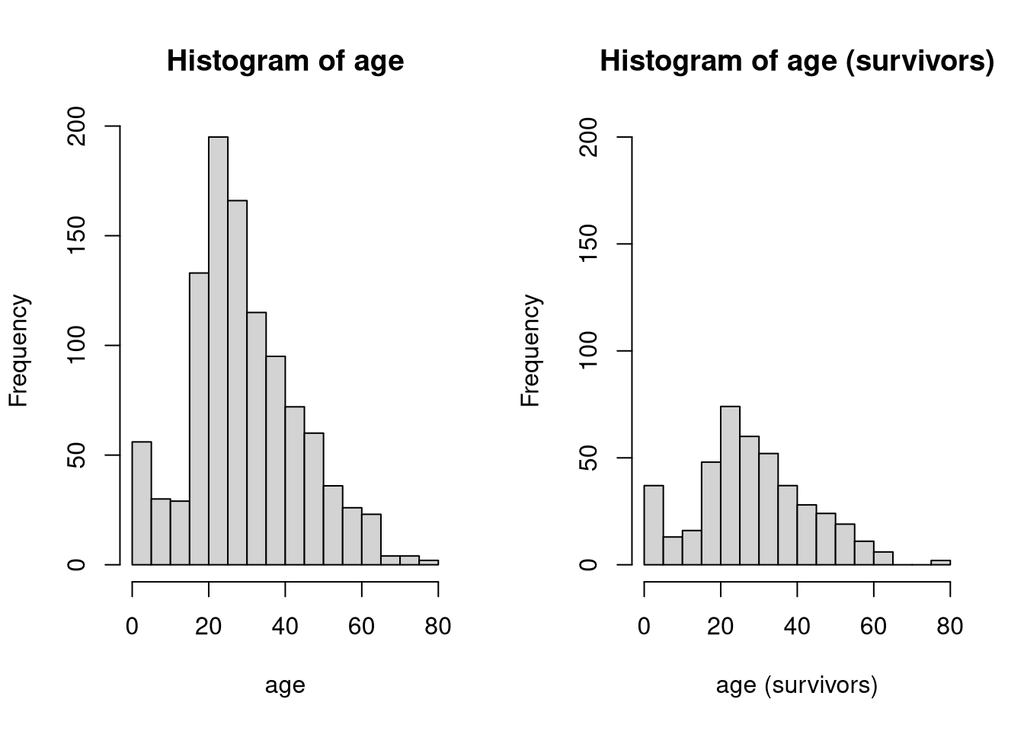

```r
age <- titanic$age
par(mfrow=c(1,2)) # two graphs side by side
hist(age, breaks = 25)
hist(age[titanic$survived == 1], breaks = 25,
     ylim = c(0,200),
     main = "Histogram of age (survivors)",
     xlab = "age (survivors)")
```

You could try to win the titanic competition on `kaggle.com` if you want.

## Examining numerical data

Last time we covered categorical data, using pie and bar charts. One method is by means of **dot plots**, useful for measuring one numerical data. If dots are sitting more to the right, which we say it’s “left-skewed”. The “center” is the *mode*, where the most observed values are (darkest area).

From probability, the center of the distribution is the median. Predominantly there are two ways at looking at the center; the mean and the median. We define the **sample mean**, denoted as $\overline{x}$, as
$$\overline{x} = \frac{x_1+x_2+ \cdots + x_n}{n}$$
where $x_1,x_2, \cdots , x_n$ represent the $n$ observed values. The sample mean is a *sample statistic*, and serves as a *point estimate* of the population mean. This estimate may not be perfect, but if the sample is good (representative of the population), it is usually a pretty good estimate. What does it mean to be a “pretty good estimate”? Usually the estimate should be within a particular radius from an “actual”.

Another way of drawing data (better than the dot plot) is the **stacked dot plot**.